# Assignment 1

David Ocepek, Matevž Eržen

8. 11. 2019

# Task 1

### What does it mean for a function to be non-convex?

*A real-valued function defined on an n-dimensional interval is called non-convex if the line segment between any two points on the graph of the function crosses the graph of the function.*

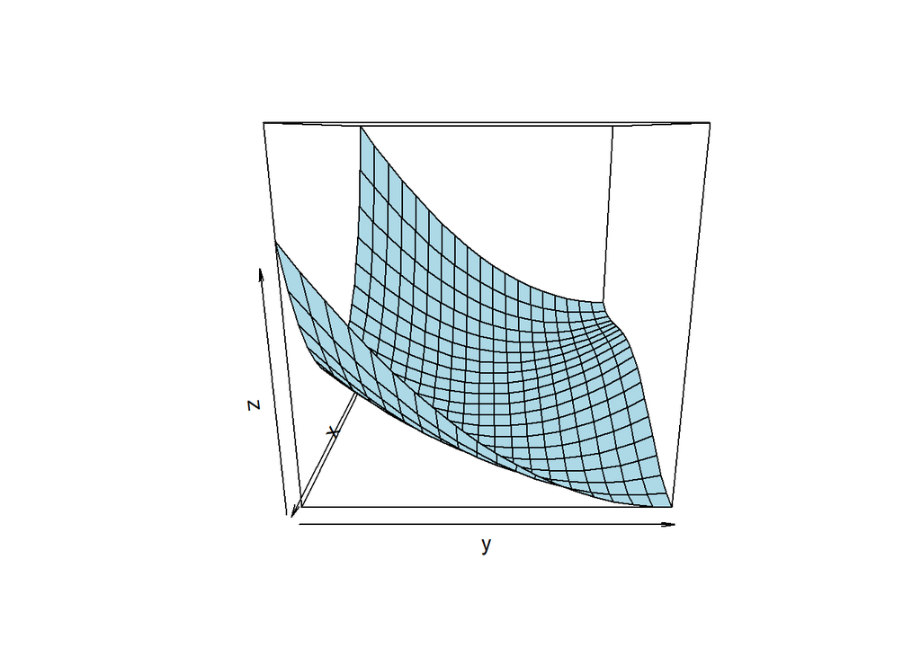

```r
f <- function(x, y)
{
  z <- (1 - x)^2 + exp(1) * (y - x^2)^2

  z
}

x <- seq(-1,1, length=20)
y <- x
z <- outer(x,y,f)

pmat <- persp(x,y,z, col="lightblue", theta=90)
```

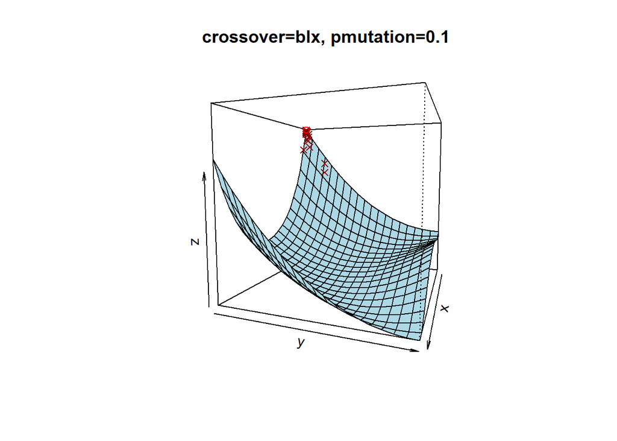

```r
p1mat <- persp(x,y,z, col="lightblue", theta=110, phi=5, main="crossover=blx, pmutation=0.1")
GA1 <- ga(type = "real-valued", fitness = function(x) f(x[1], x[2]), monitor = monitor_1, maxiter = 100, popSize = 50, lower = c(-1, -1), upper = c(1, 1), crossover = gareal_blxCrossover, pmutation = 0.1)
points(trans3d(GA1@solution[1],GA1@solution[2],f(GA1@solution[1],GA1@solution[2]),p1mat), col="red", pch=21)
```

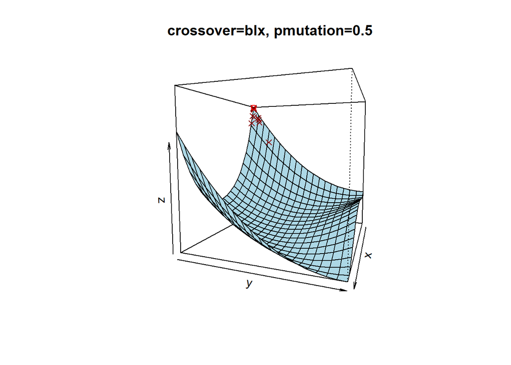

```r
p2mat <- persp(x,y,z, col="lightblue", theta=110, phi=5, main="crossover=blx, pmutation=0.5")
GA2 <- ga(type = "real-valued", fitness = function(x) f(x[1], x[2]), monitor = monitor_2, maxiter = 100, popSize = 50, lower = c(-1, -1), upper = c(1, 1), crossover = gareal_blxCrossover, pmutation = 0.5)
points(trans3d(GA2@solution[1],GA2@solution[2],f(GA2@solution[1],GA2@solution[2]),p2mat), col="red", pch=21)
```

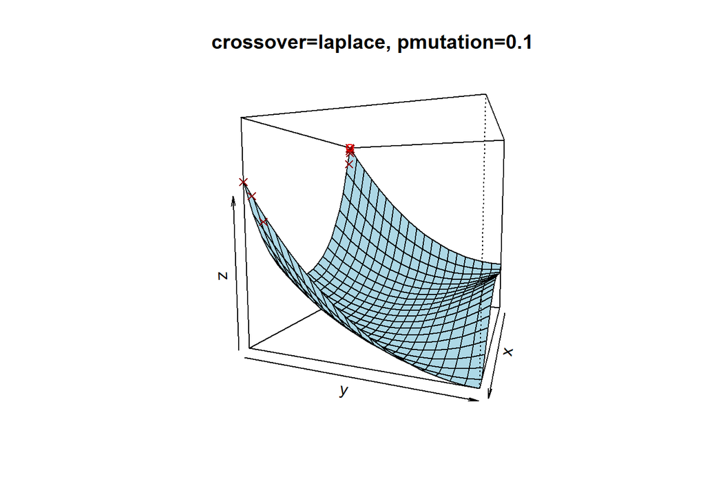

```r
p3mat <- persp(x,y,z, col="lightblue", theta=110, phi=5, main="crossover=laplace, pmutation=0.1")
GA3 <- ga(type = "real-valued", fitness = function(x) f(x[1], x[2]), monitor = monitor_3, maxiter = 100, popSize = 50, lower = c(-1, -1), upper = c(1, 1), crossover = gareal_laplaceCrossover, pmutation = 0.1)
points(trans3d(GA3@solution[1],GA3@solution[2],f(GA3@solution[1],GA3@solution[2]),p3mat), col="red", pch=21)
```

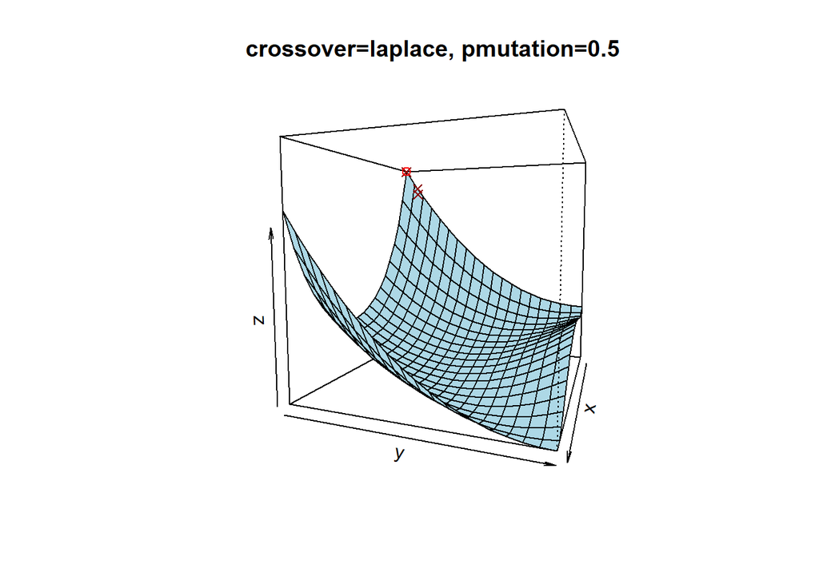

```r
p4mat <- persp(x,y,z, col="lightblue", theta=110, phi=5, main="crossover=laplace, pmutation=0.5")
GA4 <- ga(type = "real-valued", fitness = function(x) f(x[1], x[2]), monitor = monitor_4, maxiter = 100, popSize = 50, lower = c(-1, -1), upper = c(1, 1), crossover = gareal_laplaceCrossover, pmutation = 0.5)
points(trans3d(GA4@solution[1],GA4@solution[2],f(GA4@solution[1],GA4@solution[2]),p4mat), col="red", pch=21)
```

### How does performance vary when you are increasing the number of iterations?

*Function takes exponentially more time, but doesn’t produce any better results (if we are talking about >100 iterations in our case).*

### What about population size?

*Population size doesn’t cause as great difference in execution time as increase in number of iterations does, but it’s still noticable. At the same time it doesn’t make a difference if we increase the population size over certain number (in this case 10-20).*

*Both previous answers are based on results of testing on this exact problem.*

### Explain the difference between local and global maxima.

*Local maximum is the greatest element in a subset or a given range of a function. Global maximum is the greatest value among all elements in a set or values of a function. There can be multiple local maximas, while there can be only one global maximum.*

# Task 2

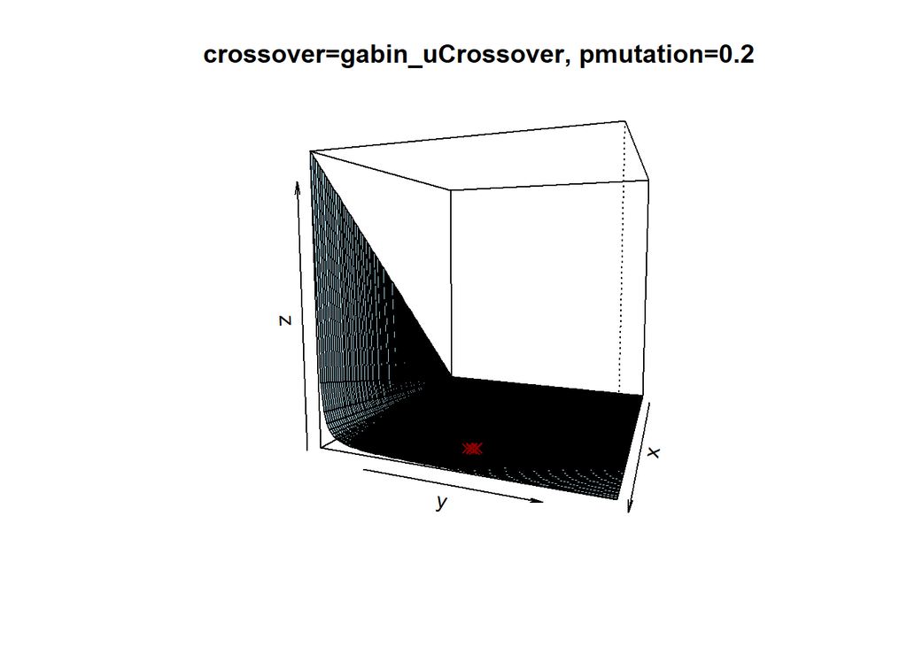

```r
data <- read.csv("C:\\Users\\david\\Downloads\\DLBCL.csv", header=TRUE, sep=",")
data$X = NULL
data$atclass = NULL

trainIndex <- createDataPartition(data$class, p = .8, list = FALSE, times = 1)
dataTrain <- data[ trainIndex,]
dataTest  <- data[-trainIndex,]

ctrl <- trainControl(
  number = 3,
  method="cv"
)

treeModel <- function(binSelection)
{
  columns <- seq(1, length(binSelection))
  selectedCol <- columns[as.logical(binSelection)]
  selectedCol <- append(selectedCol, length(binSelection) + 1, after = length(selectedCol))

  training <- select(dataTrain, selectedCol)

  plsFit <- train(
    class ~ .,
    data = training,
    method = "ctree",
    trControl = ctrl
  )

  return(plsFit)
}

fitnessFunc <- function(binSelection)
{
  if (sum(binSelection) < 2 || sum(binSelection) > 1000)
  {
    return(-1)
  }
  else
  {
    plsFit <- treeModel(binSelection)

    return(mean(plsFit$results$Accuracy)/sum(binSelection))
  }
}

f <- f <- function(x, y)
{
  z <- x/y

  z
}

x <- seq(0,1, length=100)
y <- seq(3,999, length=100)
z <- outer(x,y,f)

p5mat <- persp(x,y,z, col="lightblue", theta=110, phi=5, main="crossover=gabin_uCrossover, pmutation=0.2")

GA <- ga(
  type = "binary",
  fitness = fitnessFunc,
  monitor = monitor_5,
  crossover = gabin_uCrossover,
  elitism = 2,
  pmutation = 0.2,
  nBits = 1070,
  maxiter = 100,
  run = 10,
  popSize = 40,
  parallel = T,
  keepBest = TRUE)
```

```r
summary(GA)
```

```
## -- Genetic Algorithm -------------------
##
## GA settings:
## Type                  =  binary
## Population size       =  40
## Number of generations =  100
## Elitism               =  2
## Crossover probability =  0.8
## Mutation probability  =  0.2
##
## GA results:
## Iterations             = 24
## Fitness function value = 0.001745373
## Solution =
##      x1 x2 x3 x4 x5 x6 x7 x8 x9 x10  ...  x1069 x1070
## [1,]  1  1  1  1  0  1  0  0  1   1           1     1
```

### Was the feature selection successful?

*Feature selection was succesful. We managed to reduce the number of features by x0.57, reducing the original set of 1070 features to ~460 (varies) with no significant accuracy loss.*

### The procedure might overfit the data set. How would you prevent it?

*Overfitting is a natural and unavoidable process while training a model and the general solution is splitting the data into a training and test set. The dataset was split 80% training set and 20% test set.*

```r
# Number of features
sum(GA@solution[1,])
```

```
## [1] 482
```

```r
# Accuracy of test set and everything combined
finalFit <- treeModel(GA@solution[1,])
predicted <- predict(finalFit, dataTest)
confusionMatrix(predicted, dataTest$class)
```

```
## Confusion Matrix and Statistics
##
##           Reference
## Prediction DLBCL FL
##      DLBCL     8  0
##      FL        3  3
##
##                Accuracy : 0.7857
##                  95% CI : (0.492, 0.9534)
##     No Information Rate : 0.7857
##     P-Value [Acc > NIR] : 0.6483
##
##                   Kappa : 0.5333
##
##  Mcnemar's Test P-Value : 0.2482
##
##             Sensitivity : 0.7273
##             Specificity : 1.0000
##          Pos Pred Value : 1.0000
##          Neg Pred Value : 0.5000
##              Prevalence : 0.7857
##          Detection Rate : 0.5714
##    Detection Prevalence : 0.5714
##       Balanced Accuracy : 0.8636
##
##        'Positive' Class : DLBCL
##
```

```r
predicted <- predict(finalFit, data)
confusionMatrix(predicted, data$class)
```

```
## Confusion Matrix and Statistics
##
##           Reference
## Prediction DLBCL FL
##      DLBCL    46  0
##      FL       12 19
##
##                Accuracy : 0.8442
##                  95% CI : (0.7436, 0.9168)
##     No Information Rate : 0.7532
##     P-Value [Acc > NIR] : 0.038129
##
##                   Kappa : 0.6542
##
##  Mcnemar's Test P-Value : 0.001496
##
##             Sensitivity : 0.7931
##             Specificity : 1.0000
##          Pos Pred Value : 1.0000
##          Neg Pred Value : 0.6129
##              Prevalence : 0.7532
##          Detection Rate : 0.5974
##    Detection Prevalence : 0.5974
##       Balanced Accuracy : 0.8966
##
##        'Positive' Class : DLBCL
##
```

### Suggest how to improve the selection process.

*There is always room for improvement in terms of creating better fitness function and tweaking parameters of GA. In our case this is very much based on experimentation.*

### What are some of the key properties of the fitness function?

*Some of the key properties of the fitness function are negative values for to many or two few features, binarity of input, convexness within boundaries, …*

### Compare the final result (set of features) with the same number of features, that correlate the most with the target variable. What do you observe?

```r
cormat <- apply(data[, 1:1070], 2, cor, y = as.numeric(data$class))
lst <- sort(cormat, decreasing=TRUE)
lsttop <- head(lst, sum(GA@solution[1,]))

columns <- seq(1, 1070)
selectedCol <- columns[as.logical(GA@solution[1,])]
selectedCol <- append(selectedCol, 1071, after = length(selectedCol))
plstop <- select(data, selectedCol)

length(intersect(names(lsttop), names(data))) / sum(GA@solution[1,])
```

```
## [1] 1
```